# Montréal Urban Perceptions Meeting

Published

January 26, 2023

### Background

We want to explore how people’s perceptions of urban trees varies with their sociodemographics. Specifically, we want to dig deeper into understanding people’s perceptions in *Montréal*. We want to use the survey data to ask more pointed and meaningful questions about Montréal specifically (e.g., examine the issue of language).

There is potential for 2+ papers here. Following the first meeting, we decided that the questions of governance and management could be tackled by Emile in a separate paper, as he has a lot of expertise in this field.

This paper will be focused on questions regarding the valuation and beliefs surrounding urban trees (as opposed to questions of governance, tree knowledge, etc.)

### Proposed Research Question

How are Montréal residents’ values and beliefs concerning urban trees influenced by city type, country of origin, preferred language, dwelling type, education level?

**Justification:** People’s values and beliefs concerning urban trees are inherently died to the delivery and access of ecosystem services. To effectively manage and produce ecosystem services that truly serve people, we require knowledge surrounding what people value and what drives individual differences in values. The independent variables were selected based on the variables shown to influence street tree cover in Pham et al. (2017). In addition, we are testing the effect of city type on tree values and beliefs, as there is literature showing a divide in conceptions of nature between urban and rural residents (cite).

**Hypothesis:** values and beliefs concerning urban trees are influenced by sociodemographics directly and indirectly through exposure to trees (i.e., amount of street tree cover in your neighbourhood).

**Predictions:** would love some help from Hiên and Emile to craft some predictions for each independent variable (e.g., how do we predict level of education will influence values and beliefs concerning urban trees?). I am happy to craft them together but I think the social science expertise offered by Hiên and Emile will strengthen the predictions a lot.

### Street Tree Cover

The variables selected: country of origin, preferred language, dwelling type, and education level are all based on Pham et al. (2017), which demonstrates the relationship between these variables and *street tree cover* in Montreal. We can conceive of the relationship between these sociodemographic variables and values and beliefs surrounding urban trees as **direct** and **indirect**, where the indirect effect is the effects of sociodemographics on tree values and beliefs *through* street tree cover. This begs the question:

> Should we add street tree cover to our models?
- Without adding street tree cover, we can measure the *total effect* of sociodemographics on people’s values/beliefs (this includes the unmeasured effect of the influence of street tree cover on their values/beliefs). If we choose to add street tree cover, we can measure the *direct effect* of sociodemographics on people’s values and beliefs by controlling for street tree cover.

[figure not shown]

- To measure street tree cover, we would assign respondents a “neighbourhood” using the first 3 digits of postal codes, and then measure the average canopy cover in that area.
- Potential Issues:
  - Only 2/3 (~1,100) of respondents provided this information, so we would lose some data
  - Postal code areas have wide variation in size, especially in rural areas they are quite large, so this may not facilitate the best comparison

### Tree Values

There are 16 questions that we asked survey respondents regarding how they value urban trees. They are as follows (strikethrough indicates no significant relationship with any of our independent variable, significant relationships will be visualized below):

How important to you are each of the following things about these trees

- large old trees
- a place for human history and stories
- getting away from stresses of everyday life
- a place for a short walk
- learning about cultural traditions
- a place that is accessible for everybody
- clean air, clean water, and healthy cities
- many kinds of native animals, birds, and plants
- make the city more welcoming
- a more liveable city
- spaces for people to interact and socialize
- trees improving community cohesion
- beautiful sights, sounds, and smells
- a healthy environment that supports human life
- attracting tourists and residents to the city
- maintain Indigenous or European cultures

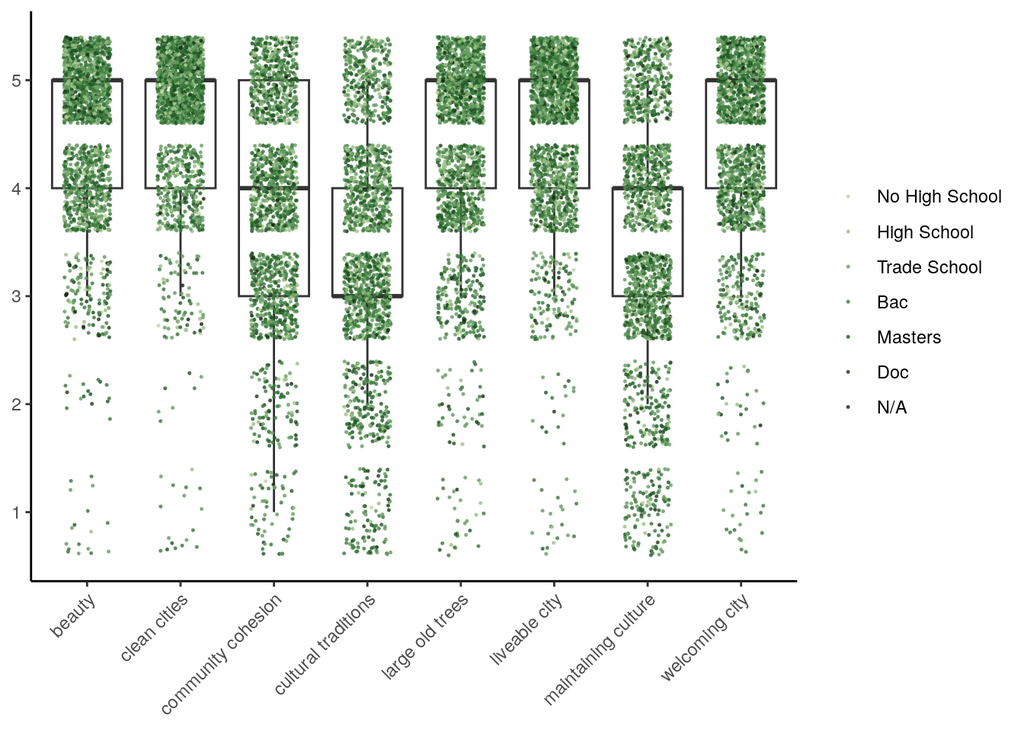

Figure 1. Questions regarding values of trees that varied significantly with level of education

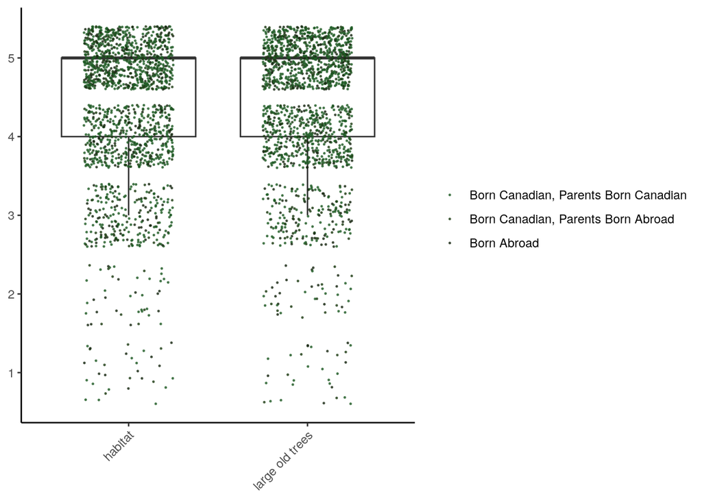

Figure 2. Questions regarding values of trees that varied significantly with country of origin

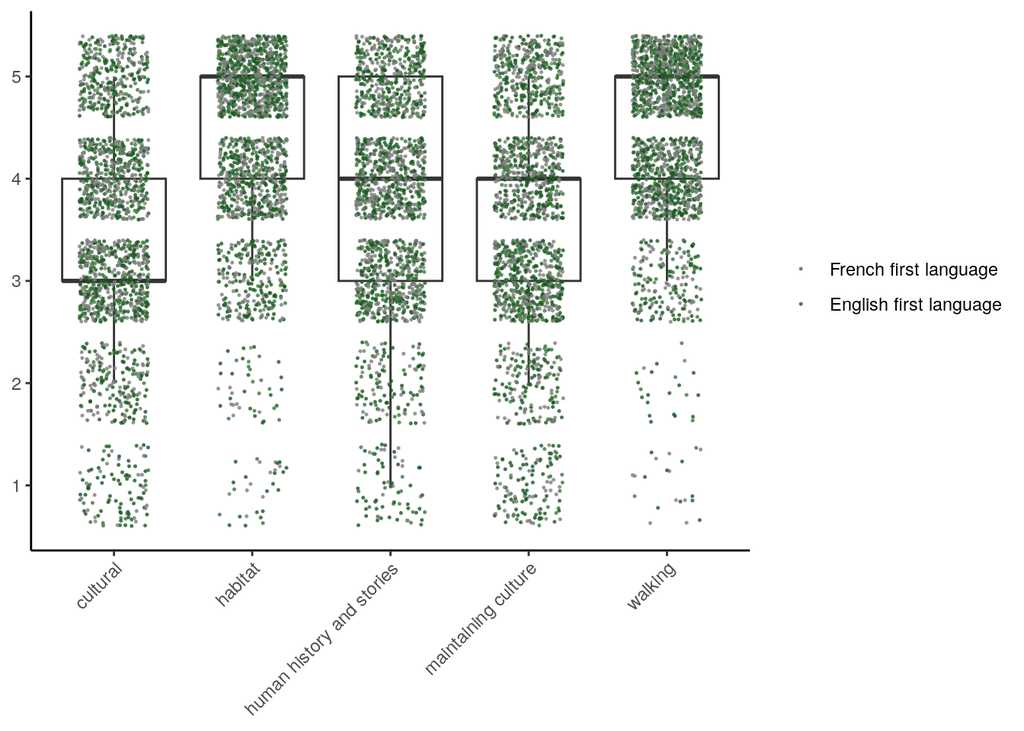

Figure 3. Questions regarding values of trees that varied significantly with first language (CODING ERROR)

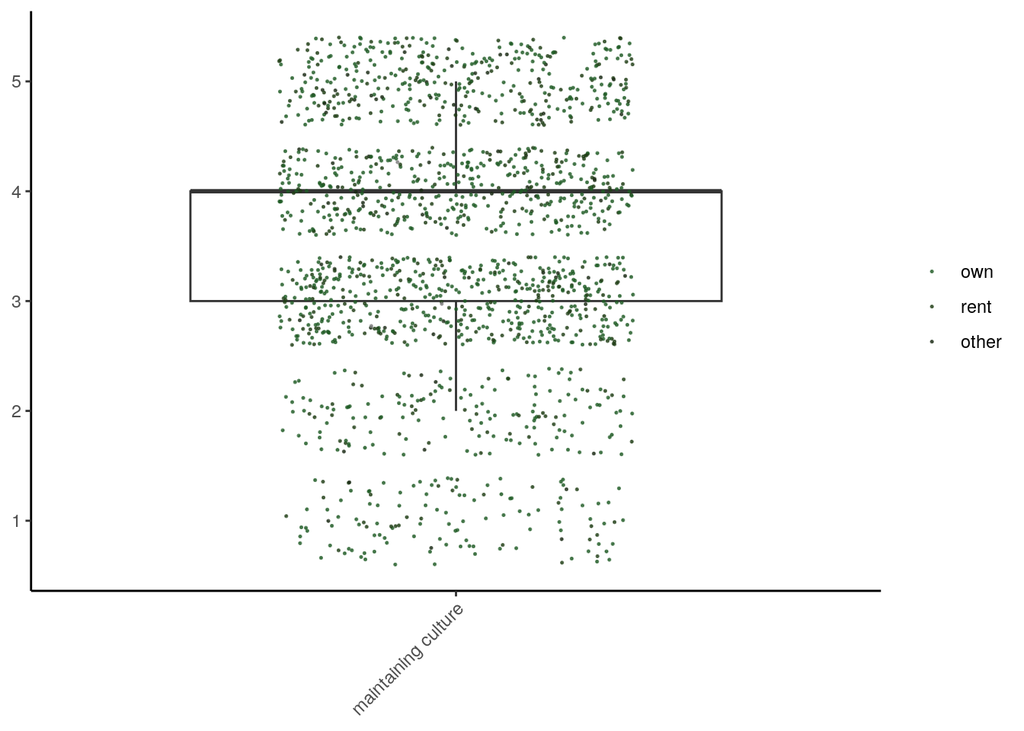

Figure 4. Questions regarding values of trees that varied significantly with home ownership

**Tree Beliefs (Negative)**

**Tree Beliefs(Positive)**

**Explanatories**